# Data visualization with ggplot2

Shorful Alam Akib

2025-04-30

*Grammar of Graphics and ggplot2*  
ggplot2 is based on the grammar of graphics, the idea that you can build every graph from the same few components: a data set, a set of geoms—visual marks that represent data points, and a coordinate system. To display data values, map variables in the data set to aesthetic properties of the geom like size, color, and x and y locations.

```r
df <- read.csv('C:/Users/USER/Desktop/!00_days_of_Coding/R/Data Science and Machine Learning Bootcamp with R By Jose Portilla/Data Visualization with ggplot2/state_real_estate_data.csv')
library(ggplot2)
```

*Quick Example with Histograms*  
Histograms are a great way of quickly exploring your data! We have a couple of options for quickly producing histograms off the columns of a data frame. We have:

hist()  
qplot()  
ggplot()

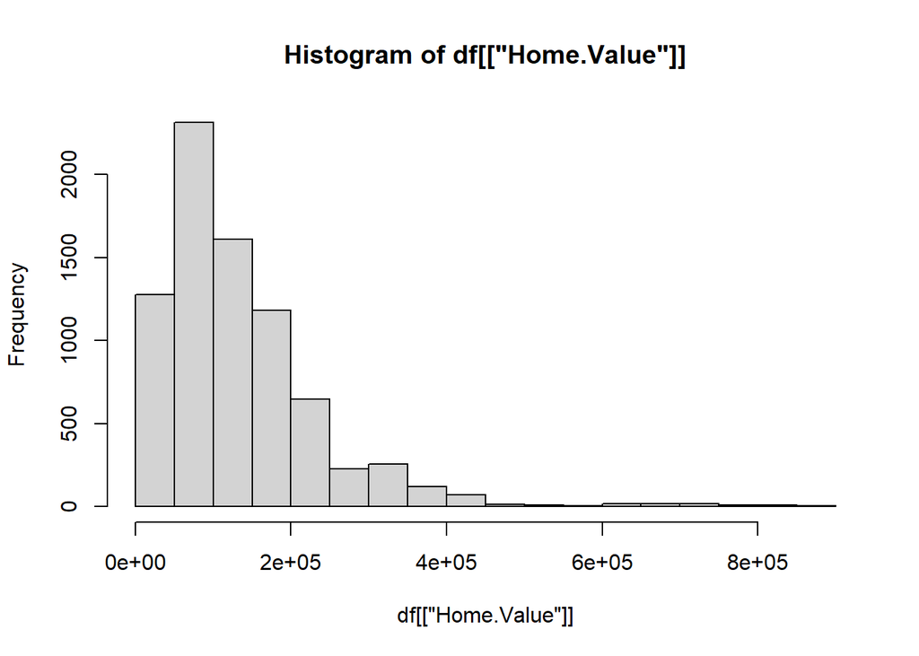

```r
hist(df[['Home.Value']])
```

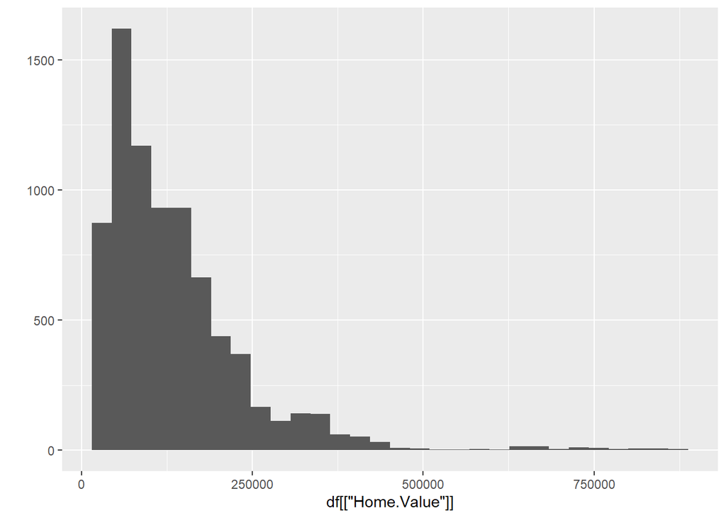

```r
qplot(df[['Home.Value']])
```

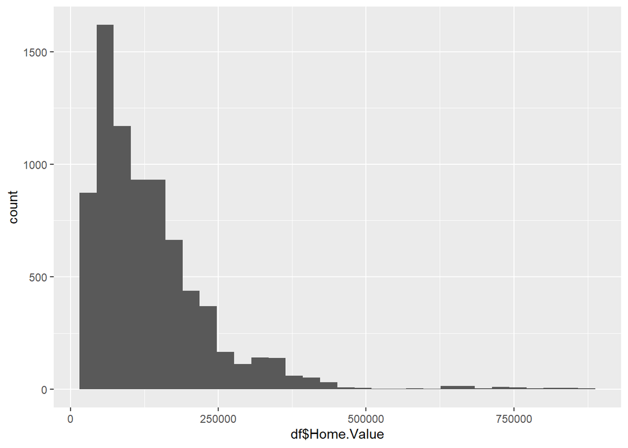

```r
ggplot(data = df,aes(df$Home.Value))+geom_histogram()
```

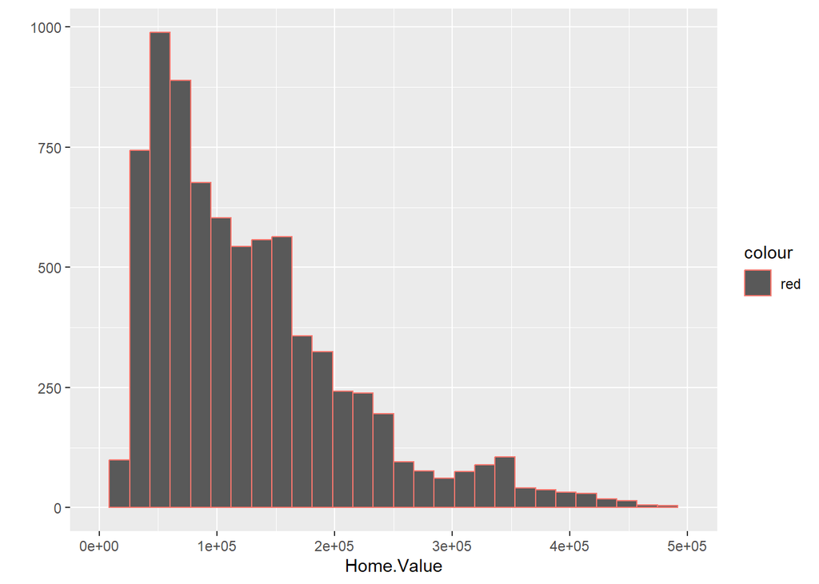

```r
qplot(data=df,x=Home.Value,geom = 'histogram',xlim=c(0,500000), color='red')
```

*Histograms with ggplot2*

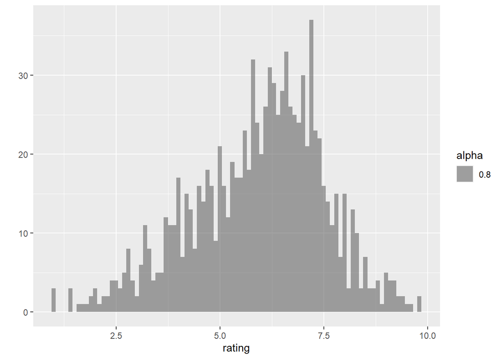

```r
library(ggplot2)
library(ggplot2movies)
df <- movies <- movies[sample(nrow(movies), 1000), ]

qplot(rating,data=df,geom='histogram',binwidth=0.1,alpha=0.8)
```

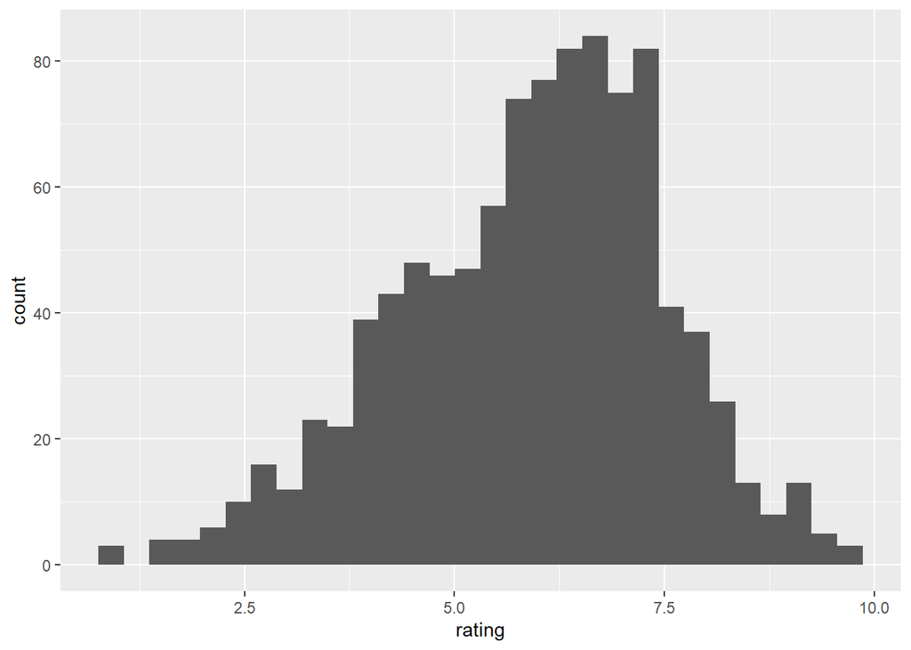

```r
# ggplot(data, aesthetics)
pl <- ggplot(df,aes(x=rating))
# Add Histogram Geometry
pl + geom_histogram()
```

Adding color

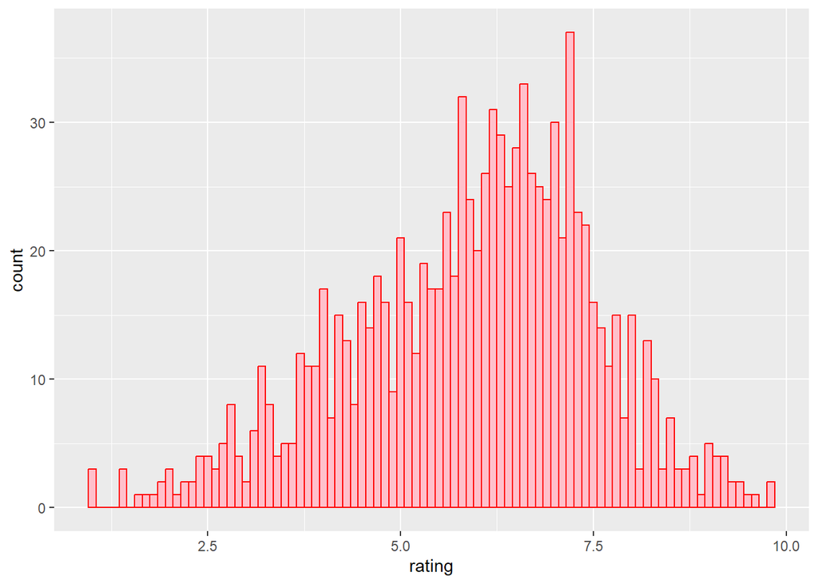

```r
pl <- ggplot(df,aes(x=rating))
pl + geom_histogram(binwidth=0.1,color='red',fill='pink')
```

Adding labels

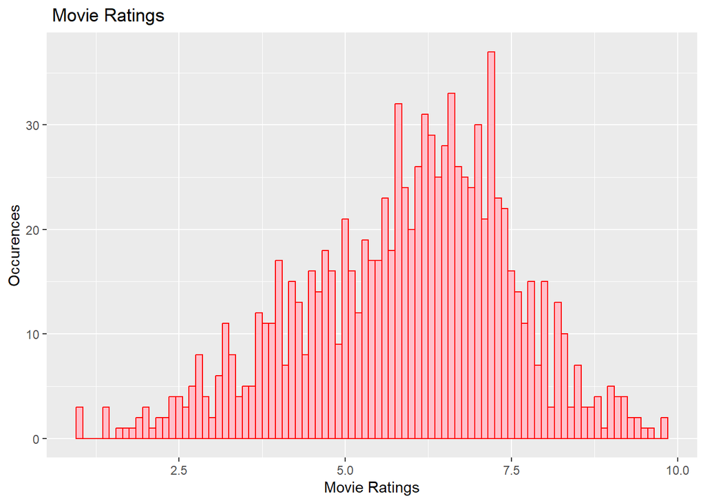

```r
pl <- ggplot(df,aes(x=rating))
pl + geom_histogram(binwidth=0.1,color='red',fill='pink') + xlab('Movie Ratings')+ ylab('Occurences') + ggtitle(' Movie Ratings')
```

Change Alpha(Transparency)

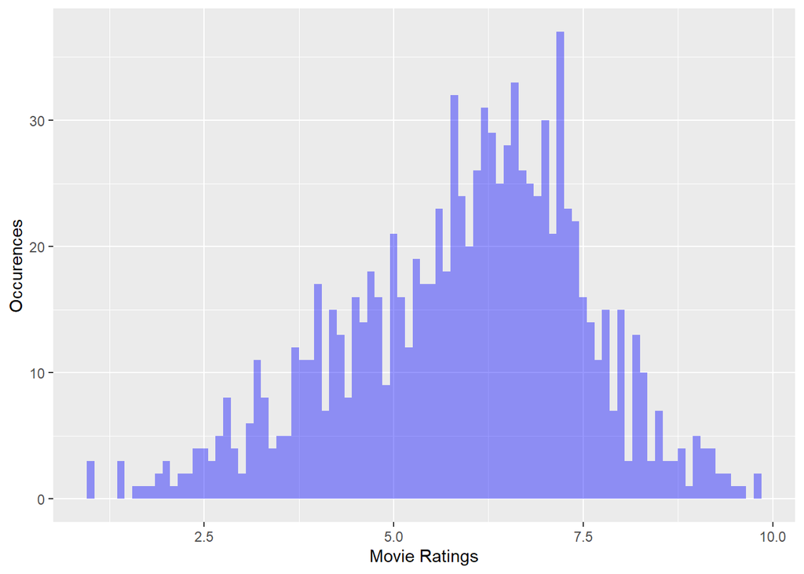

```r
pl <- ggplot(df,aes(x=rating))
pl + geom_histogram(binwidth=0.1,fill='blue',alpha=0.4) + xlab('Movie Ratings')+ ylab('Occurences')
```

Linetypes

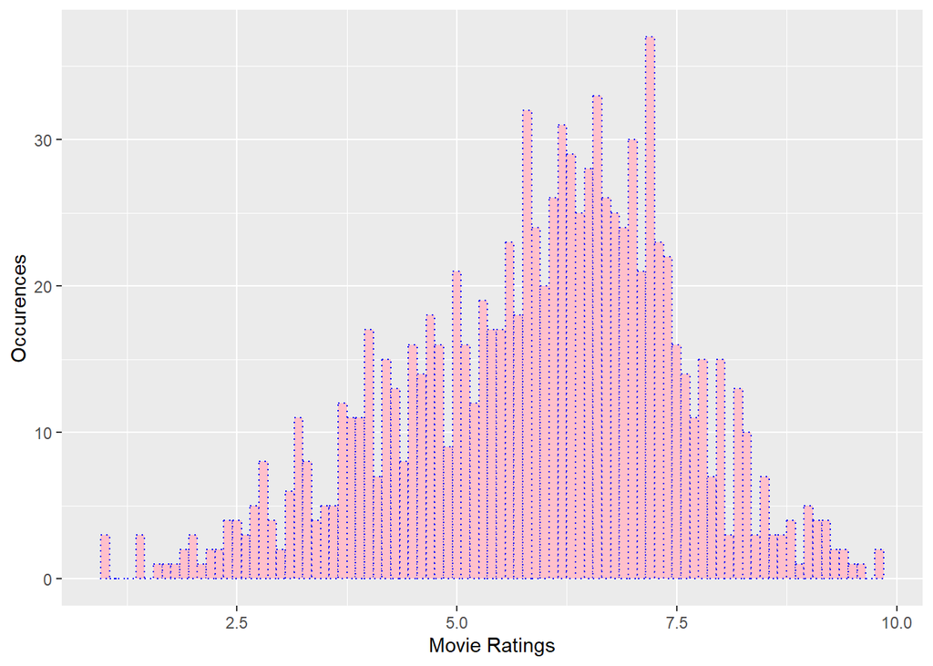

```r
pl <- ggplot(df,aes(x=rating))
pl + geom_histogram(binwidth=0.1,color='blue',fill='pink',linetype='dotted') + xlab('Movie Ratings')+ ylab('Occurences')
```

Advanced Aesthetics

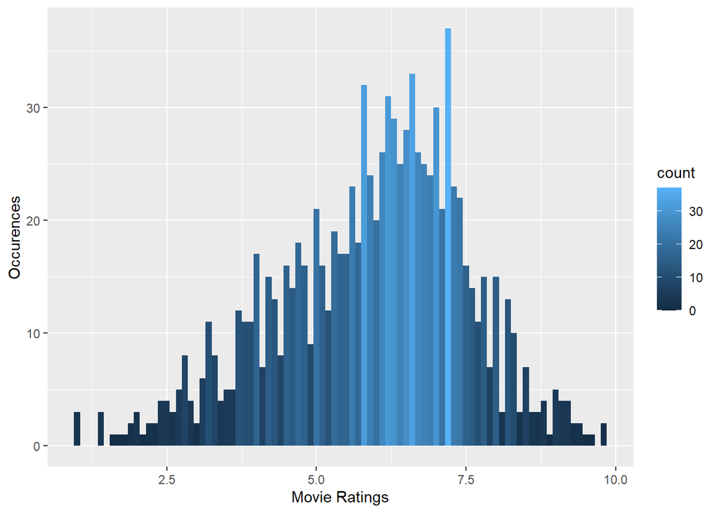

```r
# Adding Labels
pl <- ggplot(df,aes(x=rating))
pl + geom_histogram(binwidth=0.1,aes(fill=..count..)) + xlab('Movie Ratings')+ ylab('Occurences')
```